# Predicting Customer Churn

## Problem statement:

Bank XYZ has been observing a lot of customers closing their accounts.

**Objective** : Can we build a model to predict, with a reasonable accuracy, the customers who are going to churn in the near future?

**Definition of churn** : A customer having closed all their active accounts with the bank is said to have churned.

### Implementation:

```python
## Import required libraries
import pandas as pd
import numpy as np
import matplotlib.pyplot as plt
import seaborn as sns
%matplotlib inline
```

```python
## Get multiple outputs in the same cell
from IPython.core.interactiveshell import InteractiveShell
InteractiveShell.ast_node_interactivity = "all"

## Ignore all warnings
import warnings
warnings.filterwarnings('ignore')
warnings.filterwarnings(action='ignore', category=DeprecationWarning)
```

```python
## Display all rows and columns of a dataframe instead of a truncated version
from IPython.display import display
pd.set_option('display.max_columns', None)
pd.set_option('display.max_rows', None)
```

```python
## Read the dataset
df = pd.read_csv('Churn_Modelling.csv')
```

```python
df.shape
```

```
(10000, 14)
```

```python
df.head(10).T
```

|  | 0 | 1 | 2 | 3 | 4 | 5 | 6 | 7 | 8 | 9 |
| --- | --- | --- | --- | --- | --- | --- | --- | --- | --- | --- |
| RowNumber | 1 | 2 | 3 | 4 | 5 | 6 | 7 | 8 | 9 | 10 |
| CustomerId | 15634602 | 15647311 | 15619304 | 15701354 | 15737888 | 15574012 | 15592531 | 15656148 | 15792365 | 15592389 |
| Surname | Hargrave | Hill | Onio | Boni | Mitchell | Chu | Bartlett | Obinna | He | H? |
| CreditScore | 619 | 608 | 502 | 699 | 850 | 645 | 822 | 376 | 501 | 684 |
| Geography | France | Spain | France | France | Spain | Spain | France | Germany | France | France |
| Gender | Female | Female | Female | Female | Female | Male | Male | Female | Male | Male |
| Age | 42 | 41 | 42 | 39 | 43 | 44 | 50 | 29 | 44 | 27 |
| Tenure | 2 | 1 | 8 | 1 | 2 | 8 | 7 | 4 | 4 | 2 |
| Balance | 0 | 83807.9 | 159661 | 0 | 125511 | 113756 | 0 | 115047 | 142051 | 134604 |
| NumOfProducts | 1 | 1 | 3 | 2 | 1 | 2 | 2 | 4 | 2 | 1 |
| HasCrCard | 1 | 0 | 1 | 0 | 1 | 1 | 1 | 1 | 0 | 1 |
| IsActiveMember | 1 | 1 | 0 | 0 | 1 | 0 | 1 | 0 | 1 | 1 |
| EstimatedSalary | 101349 | 112543 | 113932 | 93826.6 | 79084.1 | 149757 | 10062.8 | 119347 | 74940.5 | 71725.7 |
| Exited | 1 | 0 | 1 | 0 | 0 | 1 | 0 | 1 | 0 | 0 |

### Basic EDA

```python
df.describe() # Describe all numerical columns
df.describe(include = ['O']) # Describe all non-numerical/categorical columns
```

|  | RowNumber | CustomerId | CreditScore | Age | Tenure | Balance | NumOfProducts | HasCrCard | IsActiveMember | EstimatedSalary | Exited |
| --- | --- | --- | --- | --- | --- | --- | --- | --- | --- | --- | --- |
| count | 10000.00000 | 1.000000e+04 | 10000.000000 | 10000.000000 | 10000.000000 | 10000.000000 | 10000.000000 | 10000.00000 | 10000.000000 | 10000.000000 | 10000.000000 |
| mean | 5000.50000 | 1.569094e+07 | 650.528800 | 38.921800 | 5.012800 | 76485.889288 | 1.530200 | 0.70550 | 0.515100 | 100090.239881 | 0.203700 |
| std | 2886.89568 | 7.193619e+04 | 96.653299 | 10.487806 | 2.892174 | 62397.405202 | 0.581654 | 0.45584 | 0.499797 | 57510.492818 | 0.402769 |
| min | 1.00000 | 1.556570e+07 | 350.000000 | 18.000000 | 0.000000 | 0.000000 | 1.000000 | 0.00000 | 0.000000 | 11.580000 | 0.000000 |
| 25% | 2500.75000 | 1.562853e+07 | 584.000000 | 32.000000 | 3.000000 | 0.000000 | 1.000000 | 0.00000 | 0.000000 | 51002.110000 | 0.000000 |
| 50% | 5000.50000 | 1.569074e+07 | 652.000000 | 37.000000 | 5.000000 | 97198.540000 | 1.000000 | 1.00000 | 1.000000 | 100193.915000 | 0.000000 |
| 75% | 7500.25000 | 1.575323e+07 | 718.000000 | 44.000000 | 7.000000 | 127644.240000 | 2.000000 | 1.00000 | 1.000000 | 149388.247500 | 0.000000 |
| max | 10000.00000 | 1.581569e+07 | 850.000000 | 92.000000 | 10.000000 | 250898.090000 | 4.000000 | 1.00000 | 1.000000 | 199992.480000 | 1.000000 |

|  | Surname | Geography | Gender |
| --- | --- | --- | --- |
| count | 10000 | 10000 | 10000 |
| unique | 2932 | 3 | 2 |
| top | Smith | France | Male |
| freq | 32 | 5014 | 5457 |

```python
## Checking number of unique customers in the dataset
df.shape[0], df.CustomerId.nunique()
```

```
(10000, 10000)
```

```python
df.Geography.value_counts(normalize=True)
```

```
France     0.5014
Germany    0.2509
Spain      0.2477
Name: Geography, dtype: float64
```

#### Conclusion

- Discard Row number, CustomerID, Surname as they don't convey any extra info

```python
## Separating out different columns into various categories as defined above
target_var = ['Exited']
cols_to_remove = ['RowNumber', 'CustomerId', 'Surname']
num_feats = ['CreditScore', 'Age', 'Tenure', 'Balance', 'NumOfProducts', 'EstimatedSalary']
cat_feats = [ 'Geography', 'Gender', 'HasCrCard', 'IsActiveMember']
```

Among these, Tenure and NumOfProducts are ordinal variables. HasCrCard and IsActiveMember are actually binary categorical variables.

```python
## Separating out target variable and removing the non-essential columns
y = df[target_var].values
df.drop(cols_to_remove, axis=1, inplace=True)
```

### Questioning the data :

- Some customers who have exited still have balance in their account, or a non-zero NumOfProducts. Does this mean they have churned only from a specific product and not the entire bank, or are these snapshots of just before they churned?
- Some features like, number and kind of transactions, can help us estimate the degree of activity of the customer, instead of trusting the binary variable IsActiveMember

  Here, the objective is to understand the data and distill the problem statement and the stated goal further. In the process, if more data/context can be obtained, that adds to the end result of the model performance

### Separating out train-test-valid sets

Since this is the only data available to us, we keep aside a holdout/test set to evaluate our model at the very end in order to estimate our chosen model's performance on unseen data / new data.

A validation set is also created which we'll use in our baseline models to evaluate and tune our models

```python
from sklearn.model_selection import train_test_split
```

```python
## Keeping aside a test/holdout set
df_train_val, df_test, y_train_val, y_test = train_test_split(df, y.ravel(), test_size = 0.1, random_state = 42)

## Splitting into train and validation set
df_train, df_val, y_train, y_val = train_test_split(df_train_val, y_train_val, test_size = 0.12, random_state = 42)
```

```python
df_train.shape, df_val.shape, df_test.shape, y_train.shape, y_val.shape, y_test.shape
np.mean(y_train), np.mean(y_val), np.mean(y_test)
```

```
((7920, 11), (1080, 11), (1000, 11), (7920,), (1080,), (1000,))
```

```
(0.20303030303030303, 0.22037037037037038, 0.191)
```

### Univariate plots of numerical variables in training set

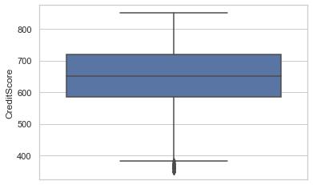

```python
## CreditScore
sns.set(style="whitegrid")
sns.boxplot(y = df_train['CreditScore']);
```

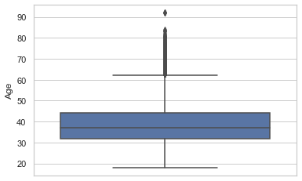

```python
## Age
sns.boxplot(y = df_train['Age']);
```

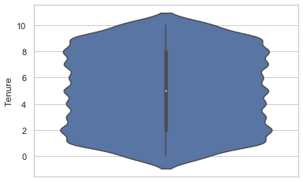

```python
## Tenure
sns.violinplot(y = df_train.Tenure);
```

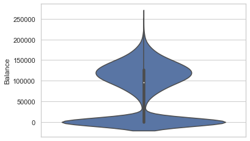

```python
## Balance
sns.violinplot(y = df_train['Balance']);
```

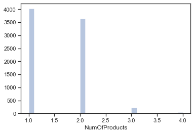

```python
## NumOfProducts
sns.set(style = 'ticks')
sns.distplot(df_train.NumOfProducts, hist=True, kde=False);
```

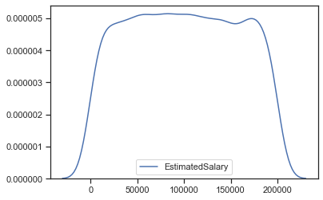

```python
## EstimatedSalary
sns.kdeplot(df_train.EstimatedSalary);
```

- From the univariate plots, we get an indication that *EstimatedSalary* , being uniformly distributed, might not turn out to be an important predictor
- Similarly, for *NumOfProducts* , there are predominantly only two values (1 and 2). Hence, its chances of being a strong predictor is also very unlikely
- On the other hand, *Balance* has a multi-modal distribution. We'll see a little later if that helps in separation of the two target classes

### Missing values and outlier treatment

#### Outliers

Outliers in numerical features can be of a very high/low value, lying in the top 1% or bottom 1% of the distribution or values which are not possible as per the feature definition.

Outliers in categorical features are usually levels with a very low frequency/no. of samples as compared to other categorical levels.

#### Missing values

```python
## No missing values!
df_train.isnull().sum()
```

```
CreditScore        0
Geography          0
Gender             0
Age                0
Tenure             0
Balance            0
NumOfProducts      0
HasCrCard          0
IsActiveMember     0
EstimatedSalary    0
Exited             0
dtype: int64
```

No missing values present in this dataset. Can also be observed from df.describe() commands.

### Categorical variable encoding

- HasCrCard and IsActiveMember are already label encoded
- For Gender, a simple Label encoding should be fine.
- For Geography, since there are 3 levels, OneHotEncoding should do the trick

#### Label Encoding for binary variables

```python
## The non-sklearn method
df_train['Gender_cat'] = df_train.Gender.astype('category').cat.codes
```

```python
df_train.sample(10)
```

|  | CreditScore | Geography | Gender | Age | Tenure | Balance | NumOfProducts | HasCrCard | IsActiveMember | EstimatedSalary | Exited | Gender_cat |
| --- | --- | --- | --- | --- | --- | --- | --- | --- | --- | --- | --- | --- |
| 9114 | 541 | France | Male | 36 | 5 | 0.00 | 2 | 1 | 0 | 124795.84 | 0 | 1 |
| 2021 | 716 | Germany | Female | 18 | 3 | 128743.80 | 1 | 0 | 0 | 197322.13 | 0 | 0 |
| 8904 | 683 | Spain | Male | 40 | 4 | 95053.10 | 1 | 1 | 1 | 116816.54 | 1 | 1 |
| 4567 | 554 | Spain | Female | 27 | 4 | 0.00 | 2 | 1 | 1 | 135083.73 | 0 | 0 |
| 2843 | 666 | Germany | Male | 38 | 6 | 99812.88 | 2 | 1 | 1 | 158357.97 | 0 | 1 |
| 9181 | 672 | France | Male | 47 | 1 | 0.00 | 1 | 0 | 0 | 91574.92 | 0 | 1 |
| 8566 | 679 | France | Female | 39 | 4 | 0.00 | 1 | 0 | 0 | 172939.30 | 1 | 0 |
| 9588 | 539 | Germany | Male | 42 | 1 | 177728.55 | 1 | 1 | 0 | 105013.63 | 0 | 1 |
| 1048 | 812 | Germany | Male | 25 | 5 | 54817.55 | 1 | 1 | 0 | 131660.31 | 0 | 1 |
| 95 | 515 | Spain | Male | 35 | 10 | 176273.95 | 1 | 0 | 1 | 121277.78 | 0 | 1 |

```python
df_train.drop('Gender_cat', axis=1, inplace = True)
```

```python
## The sklearn method
from sklearn.preprocessing import LabelEncoder
```

```python
le = LabelEncoder()
## Label encoding of Gender variable
df_train['Gender'] = le.fit_transform(df_train['Gender'])
```

```python
le_name_mapping = dict(zip(le.classes_, le.transform(le.classes_)))
le_name_mapping
```

```
{'Female': 0, 'Male': 1}
```

We fit only on train dataset as that's the only data we'll assume we have. We'll treat validation and test sets as unseen data. Hence, they can't be used for fitting the encoders.

```python
## ## Label encoding of Gender variable for validation and test set
df_val['Gender'] = df_val.Gender.map(le_name_mapping)
df_test['Gender'] = df_test.Gender.map(le_name_mapping)

## Filling missing/NaN values created due to new categorical levels
df_val['Gender'].fillna(-1, inplace=True)
df_test['Gender'].fillna(-1, inplace=True)
```

```python
df_train.Gender.unique(), df_val.Gender.unique(), df_test.Gender.unique()
```

```
(array([1, 0], dtype=int64),
 array([1, 0], dtype=int64),
 array([1, 0], dtype=int64))
```

#### One-Hot encoding for categorical variables with multiple levels

```python
from sklearn.preprocessing import LabelEncoder, OneHotEncoder
```

```python
le_ohe = LabelEncoder()
ohe = OneHotEncoder(handle_unknown = 'ignore', sparse=False)
```

```python
enc_train = le_ohe.fit_transform(df_train.Geography).reshape(df_train.shape[0],1)
enc_train.shape
np.unique(enc_train)
```

```
(7920, 1)
```

```
array([0, 1, 2])
```

```python
ohe_train = ohe.fit_transform(enc_train)
ohe_train
```

```
array([[0., 1., 0.],
       [1., 0., 0.],
       [1., 0., 0.],
       ...,
       [1., 0., 0.],
       [0., 1., 0.],
       [0., 1., 0.]])
```

```python
le_ohe_name_mapping = dict(zip(le_ohe.classes_, le_ohe.transform(le_ohe.classes_)))
le_ohe_name_mapping
```

```
{'France': 0, 'Germany': 1, 'Spain': 2}
```

```python
## Encoding Geography feature for validation and test set
enc_val = df_val.Geography.map(le_ohe_name_mapping).ravel().reshape(-1,1)
enc_test = df_test.Geography.map(le_ohe_name_mapping).ravel().reshape(-1,1)

## Filling missing/NaN values created due to new categorical levels
enc_val[np.isnan(enc_val)] = 9999
enc_test[np.isnan(enc_test)] = 9999
```

```python
np.unique(enc_val)
np.unique(enc_test)
```

```
array([0, 1, 2], dtype=int64)
```

```
array([0, 1, 2], dtype=int64)
```

```python
ohe_val = ohe.transform(enc_val)
ohe_test = ohe.transform(enc_test)
```

#### Adding the one-hot encoded columns to the dataframe and removing the original feature

```python
cols = ['country_' + str(x) for x in le_ohe_name_mapping.keys()]
cols
```

```
['country_France', 'country_Germany', 'country_Spain']
```

```python
## Adding to the respective dataframes
df_train = pd.concat([df_train.reset_index(), pd.DataFrame(ohe_train, columns = cols)], axis = 1).drop(['index'], axis=1)
df_val = pd.concat([df_val.reset_index(), pd.DataFrame(ohe_val, columns = cols)], axis = 1).drop(['index'], axis=1)
df_test = pd.concat([df_test.reset_index(), pd.DataFrame(ohe_test, columns = cols)], axis = 1).drop(['index'], axis=1)
```

```python
print("Training set")
df_train.head()
print("\n\nValidation set")
df_val.head()
print("\n\nTest set")
df_test.head()
```

```
Training set
```

|  | CreditScore | Geography | Gender | Age | Tenure | Balance | NumOfProducts | HasCrCard | IsActiveMember | EstimatedSalary | Exited | country_France | country_Germany | country_Spain |
| --- | --- | --- | --- | --- | --- | --- | --- | --- | --- | --- | --- | --- | --- | --- |
| 0 | 678 | Germany | 1 | 36 | 1 | 117864.85 | 2 | 1 | 0 | 27619.06 | 0 | 0.0 | 1.0 | 0.0 |
| 1 | 613 | France | 0 | 27 | 5 | 125167.74 | 1 | 1 | 0 | 199104.52 | 0 | 1.0 | 0.0 | 0.0 |
| 2 | 628 | France | 1 | 45 | 9 | 0.00 | 2 | 1 | 1 | 96862.56 | 0 | 1.0 | 0.0 | 0.0 |
| 3 | 513 | France | 1 | 30 | 5 | 0.00 | 2 | 1 | 0 | 162523.66 | 0 | 1.0 | 0.0 | 0.0 |
| 4 | 639 | France | 1 | 22 | 4 | 0.00 | 2 | 1 | 0 | 28188.96 | 0 | 1.0 | 0.0 | 0.0 |

```
Validation set
```

|  | CreditScore | Geography | Gender | Age | Tenure | Balance | NumOfProducts | HasCrCard | IsActiveMember | EstimatedSalary | Exited | country_France | country_Germany | country_Spain |
| --- | --- | --- | --- | --- | --- | --- | --- | --- | --- | --- | --- | --- | --- | --- |
| 0 | 757 | France | 1 | 36 | 7 | 144852.06 | 1 | 0 | 0 | 130861.95 | 0 | 1.0 | 0.0 | 0.0 |
| 1 | 552 | France | 1 | 29 | 10 | 0.00 | 2 | 1 | 0 | 12186.83 | 0 | 1.0 | 0.0 | 0.0 |
| 2 | 619 | France | 0 | 30 | 7 | 70729.17 | 1 | 1 | 1 | 160948.87 | 0 | 1.0 | 0.0 | 0.0 |
| 3 | 633 | France | 1 | 35 | 10 | 0.00 | 2 | 1 | 0 | 65675.47 | 0 | 1.0 | 0.0 | 0.0 |
| 4 | 698 | Spain | 1 | 38 | 10 | 95010.92 | 1 | 1 | 1 | 105227.86 | 0 | 0.0 | 0.0 | 1.0 |

```
Test set
```

|  | CreditScore | Geography | Gender | Age | Tenure | Balance | NumOfProducts | HasCrCard | IsActiveMember | EstimatedSalary | Exited | country_France | country_Germany | country_Spain |
| --- | --- | --- | --- | --- | --- | --- | --- | --- | --- | --- | --- | --- | --- | --- |
| 0 | 596 | Germany | 1 | 32 | 3 | 96709.07 | 2 | 0 | 0 | 41788.37 | 0 | 0.0 | 1.0 | 0.0 |
| 1 | 623 | France | 1 | 43 | 1 | 0.00 | 2 | 1 | 1 | 146379.30 | 0 | 1.0 | 0.0 | 0.0 |
| 2 | 601 | Spain | 0 | 44 | 4 | 0.00 | 2 | 1 | 0 | 58561.31 | 0 | 0.0 | 0.0 | 1.0 |
| 3 | 506 | Germany | 1 | 59 | 8 | 119152.10 | 2 | 1 | 1 | 170679.74 | 0 | 0.0 | 1.0 | 0.0 |
| 4 | 560 | Spain | 0 | 27 | 7 | 124995.98 | 1 | 1 | 1 | 114669.79 | 0 | 0.0 | 0.0 | 1.0 |

```python
## Drop the Geography column
df_train.drop(['Geography'], axis = 1, inplace=True)
df_val.drop(['Geography'], axis = 1, inplace=True)
df_test.drop(['Geography'], axis = 1, inplace=True)
```

```python
df_train.head()
df_val.head()
df_test.head()
```

|  | CreditScore | Gender | Age | Tenure | Balance | NumOfProducts | HasCrCard | IsActiveMember | EstimatedSalary | Exited | country_France | country_Germany | country_Spain |
| --- | --- | --- | --- | --- | --- | --- | --- | --- | --- | --- | --- | --- | --- |
| 0 | 678 | 1 | 36 | 1 | 117864.85 | 2 | 1 | 0 | 27619.06 | 0 | 0.0 | 1.0 | 0.0 |
| 1 | 613 | 0 | 27 | 5 | 125167.74 | 1 | 1 | 0 | 199104.52 | 0 | 1.0 | 0.0 | 0.0 |
| 2 | 628 | 1 | 45 | 9 | 0.00 | 2 | 1 | 1 | 96862.56 | 0 | 1.0 | 0.0 | 0.0 |
| 3 | 513 | 1 | 30 | 5 | 0.00 | 2 | 1 | 0 | 162523.66 | 0 | 1.0 | 0.0 | 0.0 |
| 4 | 639 | 1 | 22 | 4 | 0.00 | 2 | 1 | 0 | 28188.96 | 0 | 1.0 | 0.0 | 0.0 |

|  | CreditScore | Gender | Age | Tenure | Balance | NumOfProducts | HasCrCard | IsActiveMember | EstimatedSalary | Exited | country_France | country_Germany | country_Spain |
| --- | --- | --- | --- | --- | --- | --- | --- | --- | --- | --- | --- | --- | --- |
| 0 | 757 | 1 | 36 | 7 | 144852.06 | 1 | 0 | 0 | 130861.95 | 0 | 1.0 | 0.0 | 0.0 |
| 1 | 552 | 1 | 29 | 10 | 0.00 | 2 | 1 | 0 | 12186.83 | 0 | 1.0 | 0.0 | 0.0 |
| 2 | 619 | 0 | 30 | 7 | 70729.17 | 1 | 1 | 1 | 160948.87 | 0 | 1.0 | 0.0 | 0.0 |
| 3 | 633 | 1 | 35 | 10 | 0.00 | 2 | 1 | 0 | 65675.47 | 0 | 1.0 | 0.0 | 0.0 |
| 4 | 698 | 1 | 38 | 10 | 95010.92 | 1 | 1 | 1 | 105227.86 | 0 | 0.0 | 0.0 | 1.0 |

|  | CreditScore | Gender | Age | Tenure | Balance | NumOfProducts | HasCrCard | IsActiveMember | EstimatedSalary | Exited | country_France | country_Germany | country_Spain |
| --- | --- | --- | --- | --- | --- | --- | --- | --- | --- | --- | --- | --- | --- |
| 0 | 596 | 1 | 32 | 3 | 96709.07 | 2 | 0 | 0 | 41788.37 | 0 | 0.0 | 1.0 | 0.0 |
| 1 | 623 | 1 | 43 | 1 | 0.00 | 2 | 1 | 1 | 146379.30 | 0 | 1.0 | 0.0 | 0.0 |
| 2 | 601 | 0 | 44 | 4 | 0.00 | 2 | 1 | 0 | 58561.31 | 0 | 0.0 | 0.0 | 1.0 |
| 3 | 506 | 1 | 59 | 8 | 119152.10 | 2 | 1 | 1 | 170679.74 | 0 | 0.0 | 1.0 | 0.0 |
| 4 | 560 | 0 | 27 | 7 | 124995.98 | 1 | 1 | 1 | 114669.79 | 0 | 0.0 | 0.0 | 1.0 |

#### *Summarize* : How to handle unknown categorical levels/values in unseen data in production?

### Bivariate analysis

```python
## Check linear correlation (rho) between individual features and the target variable
corr = df_train.corr()
corr
```

|  | CreditScore | Gender | Age | Tenure | Balance | NumOfProducts | HasCrCard | IsActiveMember | EstimatedSalary | Exited | country_France | country_Germany | country_Spain |
| --- | --- | --- | --- | --- | --- | --- | --- | --- | --- | --- | --- | --- | --- |
| CreditScore | 1.000000 | 0.000354 | 0.002099 | 0.005994 | -0.001507 | 0.014110 | -0.011868 | 0.035057 | 0.000358 | -0.028117 | -0.009481 | 0.003393 | 0.007561 |
| Gender | 0.000354 | 1.000000 | -0.024446 | 0.010749 | 0.009380 | -0.026795 | 0.007550 | 0.028094 | -0.011007 | -0.102331 | 0.000823 | -0.018412 | 0.017361 |
| Age | 0.002099 | -0.024446 | 1.000000 | -0.011384 | 0.027721 | -0.033305 | -0.019633 | 0.093573 | -0.006827 | 0.288221 | -0.038881 | 0.048764 | -0.003648 |
| Tenure | 0.005994 | 0.010749 | -0.011384 | 1.000000 | -0.013081 | 0.018231 | 0.026148 | -0.021263 | 0.010145 | -0.010660 | 0.000021 | -0.003131 | 0.003090 |
| Balance | -0.001507 | 0.009380 | 0.027721 | -0.013081 | 1.000000 | -0.304318 | -0.021464 | -0.008085 | 0.027247 | 0.113377 | -0.231770 | 0.405616 | -0.136044 |
| NumOfProducts | 0.014110 | -0.026795 | -0.033305 | 0.018231 | -0.304318 | 1.000000 | 0.007202 | 0.014809 | 0.009769 | -0.039200 | 0.002991 | -0.015926 | 0.012388 |
| HasCrCard | -0.011868 | 0.007550 | -0.019633 | 0.026148 | -0.021464 | 0.007202 | 1.000000 | -0.006526 | -0.008413 | -0.013659 | 0.005881 | 0.008197 | -0.014934 |
| IsActiveMember | 0.035057 | 0.028094 | 0.093573 | -0.021263 | -0.008085 | 0.014809 | -0.006526 | 1.000000 | -0.016446 | -0.152477 | 0.002126 | -0.020570 | 0.018003 |
| EstimatedSalary | 0.000358 | -0.011007 | -0.006827 | 0.010145 | 0.027247 | 0.009769 | -0.008413 | -0.016446 | 1.000000 | 0.015881 | -0.004512 | 0.010583 | -0.005320 |
| Exited | -0.028117 | -0.102331 | 0.288221 | -0.010660 | 0.113377 | -0.039200 | -0.013659 | -0.152477 | 0.015881 | 1.000000 | -0.106006 | 0.173492 | -0.050264 |
| country_France | -0.009481 | 0.000823 | -0.038881 | 0.000021 | -0.231770 | 0.002991 | 0.005881 | 0.002126 | -0.004512 | -0.106006 | 1.000000 | -0.575048 | -0.581494 |
| country_Germany | 0.003393 | -0.018412 | 0.048764 | -0.003131 | 0.405616 | -0.015926 | 0.008197 | -0.020570 | 0.010583 | 0.173492 | -0.575048 | 1.000000 | -0.331194 |
| country_Spain | 0.007561 | 0.017361 | -0.003648 | 0.003090 | -0.136044 | 0.012388 | -0.014934 | 0.018003 | -0.005320 | -0.050264 | -0.581494 | -0.331194 | 1.000000 |

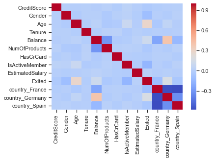

```python
sns.heatmap(corr, cmap = 'coolwarm');
```

None of the features are highly correlated with the target variable. But some of them have slight linear associations with the target variable.

- Continuous features - Age, Balance
- Categorical variables - Gender, IsActiveMember, country_Germany, country_France

#### Individual features versus their distibution across target variable values

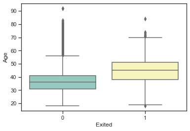

```python
sns.boxplot(x = "Exited", y = "Age", data = df_train, palette="Set3");
```

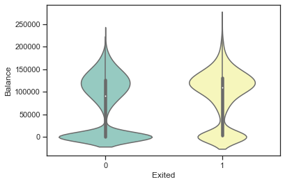

```python
sns.violinplot(x = "Exited", y = "Balance", data = df_train, palette="Set3");
```

```python
# Check association of categorical features with target variable
cat_vars_bv = ['Gender', 'IsActiveMember', 'country_Germany', 'country_France']

for col in cat_vars_bv:
    df_train.groupby([col]).Exited.mean()
```

```
Gender
0    0.248191
1    0.165511
Name: Exited, dtype: float64
```

```
IsActiveMember
0    0.266285
1    0.143557
Name: Exited, dtype: float64
```

```
country_Germany
0.0    0.163091
1.0    0.324974
Name: Exited, dtype: float64
```

```
country_France
0.0    0.245877
1.0    0.160593
Name: Exited, dtype: float64
```

```python
col = 'NumOfProducts'
df_train.groupby([col]).Exited.mean()
df_train[col].value_counts()
```

```
NumOfProducts
1    0.273428
2    0.076881
3    0.825112
4    1.000000
Name: Exited, dtype: float64
```

```
1    4023
2    3629
3     223
4      45
Name: NumOfProducts, dtype: int64
```

### Some basic feature engineering

```python
df_train.columns
```

```
Index(['CreditScore', 'Gender', 'Age', 'Tenure', 'Balance', 'NumOfProducts',
       'HasCrCard', 'IsActiveMember', 'EstimatedSalary', 'Exited',
       'country_France', 'country_Germany', 'country_Spain'],
      dtype='object')
```

Creating some new features based on simple interactions between the existing features.

- Balance/NumOfProducts
- Balance/EstimatedSalary
- Tenure/Age

```python
eps = 1e-6

df_train['bal_per_product'] = df_train.Balance/(df_train.NumOfProducts + eps)
df_train['bal_by_est_salary'] = df_train.Balance/(df_train.EstimatedSalary + eps)
df_train['tenure_age_ratio'] = df_train.Tenure/(df_train.Age + eps)
```

```python
df_train.head()
```

|  | CreditScore | Gender | Age | Tenure | Balance | NumOfProducts | HasCrCard | IsActiveMember | EstimatedSalary | Exited | country_France | country_Germany | country_Spain | bal_per_product | bal_by_est_salary | tenure_age_ratio |
| --- | --- | --- | --- | --- | --- | --- | --- | --- | --- | --- | --- | --- | --- | --- | --- | --- |
| 0 | 678 | 1 | 36 | 1 | 117864.85 | 2 | 1 | 0 | 27619.06 | 0 | 0.0 | 1.0 | 0.0 | 58932.395534 | 4.267519 | 0.027778 |
| 1 | 613 | 0 | 27 | 5 | 125167.74 | 1 | 1 | 0 | 199104.52 | 0 | 1.0 | 0.0 | 0.0 | 125167.614832 | 0.628653 | 0.185185 |
| 2 | 628 | 1 | 45 | 9 | 0.00 | 2 | 1 | 1 | 96862.56 | 0 | 1.0 | 0.0 | 0.0 | 0.000000 | 0.000000 | 0.200000 |
| 3 | 513 | 1 | 30 | 5 | 0.00 | 2 | 1 | 0 | 162523.66 | 0 | 1.0 | 0.0 | 0.0 | 0.000000 | 0.000000 | 0.166667 |
| 4 | 639 | 1 | 22 | 4 | 0.00 | 2 | 1 | 0 | 28188.96 | 0 | 1.0 | 0.0 | 0.0 | 0.000000 | 0.000000 | 0.181818 |

```python
new_cols = ['bal_per_product','bal_by_est_salary','tenure_age_ratio']
```

```python
## Ensuring that the new column doesn't have any missing values
df_train[new_cols].isnull().sum()
```

```
bal_per_product      0
bal_by_est_salary    0
tenure_age_ratio     0
dtype: int64
```

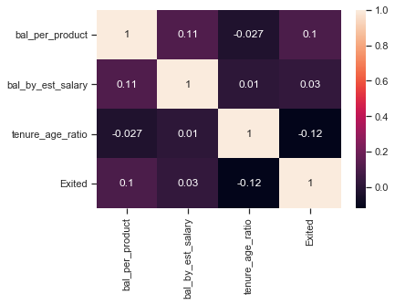

```python
## Linear association of new columns with target variables to judge importance
sns.heatmap(df_train[new_cols + ['Exited']].corr(), annot=True)
```

Out of the new features, ones with slight linear association/correlation are : bal_per_product and tenure_age_ratio

```python
## Creating new interaction feature terms for validation set
eps = 1e-6

df_val['bal_per_product'] = df_val.Balance/(df_val.NumOfProducts + eps)
df_val['bal_by_est_salary'] = df_val.Balance/(df_val.EstimatedSalary + eps)
df_val['tenure_age_ratio'] = df_val.Tenure/(df_val.Age + eps)
```

```python
## Creating new interaction feature terms for test set
eps = 1e-6

df_test['bal_per_product'] = df_test.Balance/(df_test.NumOfProducts + eps)
df_test['bal_by_est_salary'] = df_test.Balance/(df_test.EstimatedSalary + eps)
df_test['tenure_age_ratio'] = df_test.Tenure/(df_test.Age + eps)
```

### Feature scaling and normalization

#### Feature transformations

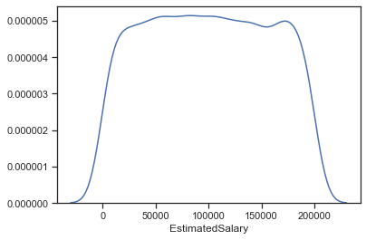

```python
### Sample feature transformation
sns.distplot(df_train.EstimatedSalary, hist=False);
```

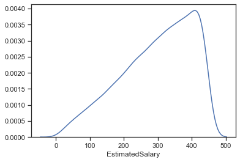

```python
sns.distplot(np.sqrt(df_train.EstimatedSalary), hist=False);
#sns.distplot(np.log10(1+df_train.EstimatedSalary), hist=False);
```

#### StandardScaler

```python
from sklearn.preprocessing import StandardScaler
sc = StandardScaler()
```

```python
df_train.columns
```

```
Index(['CreditScore', 'Gender', 'Age', 'Tenure', 'Balance', 'NumOfProducts',
       'HasCrCard', 'IsActiveMember', 'EstimatedSalary', 'Exited',
       'country_France', 'country_Germany', 'country_Spain', 'bal_per_product',
       'bal_by_est_salary', 'tenure_age_ratio'],
      dtype='object')
```

Scaling only continuous variables

```python
cont_vars = ['CreditScore', 'Age', 'Tenure', 'Balance', 'NumOfProducts', 'EstimatedSalary', 'bal_per_product'
             , 'bal_by_est_salary', 'tenure_age_ratio']
cat_vars = ['Gender', 'HasCrCard', 'IsActiveMember', 'country_France', 'country_Germany', 'country_Spain']
```

```python
## Scaling only continuous columns
cols_to_scale = cont_vars
```

```python
sc_X_train = sc.fit_transform(df_train[cols_to_scale])
```

```python
## Converting from array to dataframe and naming the respective features/columns
sc_X_train = pd.DataFrame(data = sc_X_train, columns = cols_to_scale)
sc_X_train.shape
sc_X_train.head()
```

```
(7920, 9)
```

|  | CreditScore | Age | Tenure | Balance | NumOfProducts | EstimatedSalary | bal_per_product | bal_by_est_salary | tenure_age_ratio |
| --- | --- | --- | --- | --- | --- | --- | --- | --- | --- |
| 0 | 0.284761 | -0.274383 | -1.389130 | 0.670778 | 0.804059 | -1.254732 | -0.062389 | 0.095448 | -1.232035 |
| 1 | -0.389351 | -1.128482 | -0.004763 | 0.787860 | -0.912423 | 1.731950 | 1.104840 | -0.118834 | 0.525547 |
| 2 | -0.233786 | 0.579716 | 1.379604 | -1.218873 | 0.804059 | -0.048751 | -1.100925 | -0.155854 | 0.690966 |
| 3 | -1.426446 | -0.843782 | -0.004763 | -1.218873 | 0.804059 | 1.094838 | -1.100925 | -0.155854 | 0.318773 |
| 4 | -0.119706 | -1.602981 | -0.350855 | -1.218873 | 0.804059 | -1.244806 | -1.100925 | -0.155854 | 0.487952 |

```python
## Mapping learnt on the continuous features
sc_map = {'mean':sc.mean_, 'std':np.sqrt(sc.var_)}
sc_map
```

```
{'mean': array([6.50542424e+02, 3.88912879e+01, 5.01376263e+00, 7.60258447e+04,
        1.53156566e+00, 9.96616540e+04, 6.24727199e+04, 2.64665647e+00,
        1.38117689e-01]),
 'std': array([9.64231806e+01, 1.05374237e+01, 2.88940724e+00, 6.23738902e+04,
        5.82587032e-01, 5.74167173e+04, 5.67456646e+04, 1.69816787e+01,
        8.95590667e-02])}
```

```python
## Scaling validation and test sets by transforming the mapping obtained through the training set
sc_X_val = sc.transform(df_val[cols_to_scale])
sc_X_test = sc.transform(df_test[cols_to_scale])
```

```python
## Converting val and test arrays to dataframes for re-usability
sc_X_val = pd.DataFrame(data = sc_X_val, columns = cols_to_scale)
sc_X_test = pd.DataFrame(data = sc_X_test, columns = cols_to_scale)
```

Feature scaling is important for algorithms like Logistic Regression and SVM. Not necessary for Tree-based models

### Feature selection - RFE

Features shortlisted through EDA/manual inspection and bivariate analysis :

*Age, Gender, Balance, NumOfProducts, IsActiveMember, the 3 country/Geography variables, bal per product, tenure age ratio*

Now, let's see whether feature selection/elimination through RFE (Recursive Feature Elimination) gives us the same list of features, other extra features or lesser number of features.

To begin with, we'll feed all features to RFE + LogReg model.

```python
cont_vars
cat_vars
```

```
['CreditScore',
 'Age',
 'Tenure',
 'Balance',
 'NumOfProducts',
 'EstimatedSalary',
 'bal_per_product',
 'bal_by_est_salary',
 'tenure_age_ratio']
```

```
['Gender',
 'HasCrCard',
 'IsActiveMember',
 'country_France',
 'country_Germany',
 'country_Spain']
```

```python
## Creating feature-set and target for RFE model
y = df_train['Exited'].values
X = pd.concat([df_train[cat_vars], sc_X_train[cont_vars]], ignore_index=True, axis = 1)
#X = df_train[cat_vars + cont_vars]
X.columns = cat_vars + cont_vars
```

```python
from sklearn.feature_selection import RFE
from sklearn.linear_model import LogisticRegression
from sklearn.tree import DecisionTreeClassifier
```

```python
est = LogisticRegression()
#est = DecisionTreeClassifier(max_depth = 4, criterion = 'entropy')
num_features_to_select = 10
```

```python
rfe = RFE(est, num_features_to_select)
rfe = rfe.fit(X.values, y)
print(rfe.support_)
print(rfe.ranking_)
```

```
[ True False  True  True  True  True  True  True  True  True False False
 False False  True]
[1 2 1 1 1 1 1 1 1 1 5 4 6 3 1]
```

```python
## Logistic Regression (Linear model)
mask = rfe.support_.tolist()
selected_feats = [b for a,b in zip(mask, X.columns) if a]
selected_feats
```

```
['Gender',
 'IsActiveMember',
 'country_France',
 'country_Germany',
 'country_Spain',
 'CreditScore',
 'Age',
 'Tenure',
 'Balance',
 'tenure_age_ratio']
```

```python
## Decision Tree (Non-linear model)
mask = rfe.support_.tolist()
selected_feats_dt = [b for a,b in zip(mask, X.columns) if a]
selected_feats_dt
```

```
['Gender',
 'IsActiveMember',
 'country_France',
 'country_Germany',
 'country_Spain',
 'CreditScore',
 'Age',
 'Tenure',
 'Balance',
 'tenure_age_ratio']
```

### Baseline model : Logistic Regression

We'll train the linear models on the features selected through RFE

```python
from sklearn.linear_model import LogisticRegression
```

```python
## Importing relevant metrics
from sklearn.metrics import roc_auc_score, auc, f1_score, recall_score, confusion_matrix, classification_report
```

```python
selected_cat_vars = [x for x in selected_feats if x in cat_vars]
selected_cont_vars = [x for x in selected_feats if x in cont_vars]
```

```python
## Using categorical features and scaled numerical features
X_train = np.concatenate((df_train[selected_cat_vars].values, sc_X_train[selected_cont_vars].values), axis = 1)
X_val = np.concatenate((df_val[selected_cat_vars].values, sc_X_val[selected_cont_vars].values), axis = 1)
X_test = np.concatenate((df_test[selected_cat_vars].values, sc_X_test[selected_cont_vars].values), axis = 1)

X_train.shape, X_val.shape, X_test.shape
```

```
((7920, 10), (1080, 10), (1000, 10))
```

- #### Solving class imbalance

```python
# Obtaining class weights based on the class samples imbalance ratio
_, num_samples = np.unique(y_train, return_counts = True)
weights = np.max(num_samples)/num_samples
weights
num_samples
```

```
array([1.        , 3.92537313])
```

```
array([6312, 1608], dtype=int64)
```

```python
weights_dict = dict()
class_labels = [0,1]
for a,b in zip(class_labels,weights):
    weights_dict[a] = b

weights_dict
```

```
{0: 1.0, 1: 3.925373134328358}
```

```python
## Defining model
lr = LogisticRegression(C = 1.0, penalty = 'l2', class_weight = weights_dict, n_jobs = -1)
```

```python
## Fitting model
lr.fit(X_train, y_train)
```

```
LogisticRegression(class_weight={0: 1.0, 1: 3.925373134328358}, n_jobs=-1)
```

```python
## Fitted model parameters
selected_cat_vars + selected_cont_vars

lr.coef_
lr.intercept_
```

```
['Gender',
 'IsActiveMember',
 'country_France',
 'country_Germany',
 'country_Spain',
 'CreditScore',
 'Age',
 'Tenure',
 'Balance',
 'tenure_age_ratio']
```

```
array([[-0.52653217, -0.90462127, -0.29044964,  0.48799186, -0.19625691,
        -0.0692901 ,  0.71816397,  0.24032536,  0.16975955, -0.32175463]])
```

```
array([0.52967547])
```

```python
## Importing relevant metrics
from sklearn.metrics import roc_auc_score, roc_curve, precision_recall_curve, f1_score, recall_score, confusion_matrix, classification_report

# function to get AUC, Recall Score, Confusion matrix, Classification report
def get_model_metrics(model_name, model, X, y):
    y_pred = model.predict(X)
    get_metrics(y, y_pred)

def get_draw_model_metrics(model_name, model, X, y):
    y_pred = model.predict(X)
    get_metrics(y, y_pred)
    draw_roc_curve(model_name, model, X, y)
    draw_precision_recall(model_name, model, X, y)

def get_metrics(y, y_pred):
    print('ROC_AUC_Score: ', roc_auc_score(y, y_pred))
    print('Recall Score: ', recall_score(y, y_pred))
    print('\nConfusion Matrix')
    print(pd.DataFrame(confusion_matrix(y, y_pred)))
    print('\nClassification Report')
    print(classification_report(y, y_pred))

# function to draw ROC and Precision/Recall Curves
def draw_roc_curve(model_name, model, X, y):
    base_probs = [0 for _ in range(len(y))]
    all_probs = model.predict_proba(X)
    # keep probabilities for the positive outcome only
    class_probs = all_probs[:,1]
    # calculate scores
    ns_auc = roc_auc_score(y, base_probs)
    model_auc = roc_auc_score(y, class_probs)
    # summarize scores
    print('Base: ROC AUC=%.3f' % (ns_auc))
    print(model_name + ': ROC AUC=%.3f' % (model_auc))
    # calculate roc curves
    ns_fpr, ns_tpr, _ = roc_curve(y, base_probs)
    lr_fpr, lr_tpr, _ = roc_curve(y, class_probs)
    # plot the roc curve for the model
    plt.plot(ns_fpr, ns_tpr, linestyle='--', label='Base')
    plt.plot(lr_fpr, lr_tpr, marker='.', label=model_name)
    # axis labels
    plt.xlabel('False Positive Rate')
    plt.ylabel('True Positive Rate')
    # show the legend
    plt.legend()
    # show the plot
    plt.show();

def draw_precision_recall(model_name, model, X, y):
    base_probs = [0 for _ in range(len(y))]
    all_probs = model.predict_proba(X)
    y_pred = model.predict(X)
    # keep probabilities for the positive outcome only
    class_probs = all_probs[:,1]
    # calculate scores
    lr_precision, lr_recall, _ = precision_recall_curve(y, class_probs)
    lr_f1, lr_auc = f1_score(y, y_pred), auc(lr_recall, lr_precision)
    # summarize scores
    print(model_name + ': f1=%.3f auc=%.3f' % (lr_f1, lr_auc))
    # plot the precision-recall curves
    no_skill = len(y[y==1]) / len(y)
    plt.plot([0, 1], [no_skill, no_skill], linestyle='--', label='Base')
    plt.plot(lr_recall, lr_precision, marker='.', label=model_name)
    # axis labels
    plt.xlabel('Recall')
    plt.ylabel('Precision')
    # show the legend
    plt.legend()
    # show the plot
    plt.show();
```

```
ROC_AUC_Score:  0.7080578571023212
Recall Score:  0.7039800995024875

Confusion Matrix
      0     1
0  4495  1817
1   476  1132

Classification Report
              precision    recall  f1-score   support

           0       0.90      0.71      0.80      6312
           1       0.38      0.70      0.50      1608

    accuracy                           0.71      7920
   macro avg       0.64      0.71      0.65      7920
weighted avg       0.80      0.71      0.74      7920

Base: ROC AUC=0.500
Logistic: ROC AUC=0.770
```

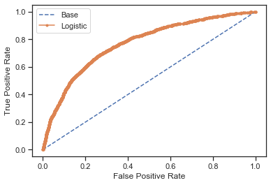

```
Logistic: f1=0.497 auc=0.460
```

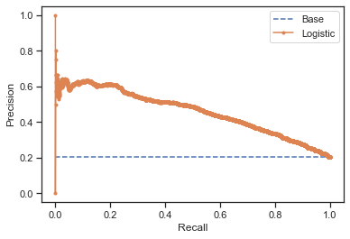

```python
## Training metrics
get_draw_model_metrics('Logistic', lr, X_train, y_train)
```

```
ROC_AUC_Score:  0.6964011257709735
Recall Score:  0.6932773109243697

Confusion Matrix
     0    1
0  589  253
1   73  165

Classification Report
              precision    recall  f1-score   support

           0       0.89      0.70      0.78       842
           1       0.39      0.69      0.50       238

    accuracy                           0.70      1080
   macro avg       0.64      0.70      0.64      1080
weighted avg       0.78      0.70      0.72      1080

Base: ROC AUC=0.500
Logistic On validation test: ROC AUC=0.771
```

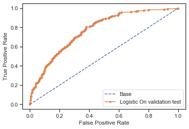

```
Logistic On validation test: f1=0.503 auc=0.484
```

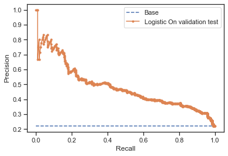

```python
## Validation metrics
get_draw_model_metrics('Logistic On validation test', lr, X_val, y_val)
```

### More linear models - SVM

```python
from sklearn.svm import SVC
```

```python
## Using categorical features and scaled numerical features
X_train = np.concatenate((df_train[selected_cat_vars].values, sc_X_train[selected_cont_vars].values), axis = 1)
X_val = np.concatenate((df_val[selected_cat_vars].values, sc_X_val[selected_cont_vars].values), axis = 1)
X_test = np.concatenate((df_test[selected_cat_vars].values, sc_X_test[selected_cont_vars].values), axis = 1)

X_train.shape, X_val.shape, X_test.shape
```

```
((7920, 10), (1080, 10), (1000, 10))
```

```python
weights_dict = {0: 1.0, 1: 3.92}
weights_dict
```

```
{0: 1.0, 1: 3.92}
```

```python
svm = SVC(C = 1.0, kernel = "linear", class_weight = weights_dict)
```

```python
svm.fit(X_train, y_train)
```

```
SVC(class_weight={0: 1.0, 1: 3.92}, kernel='linear')
```

```python
## Fitted model parameters
selected_cat_vars + selected_cont_vars

svm.coef_
svm.intercept_
```

```
['Gender',
 'IsActiveMember',
 'country_France',
 'country_Germany',
 'country_Spain',
 'CreditScore',
 'Age',
 'Tenure',
 'Balance',
 'tenure_age_ratio']
```

```
array([[-0.47676129, -0.73195804, -0.25087097,  0.47024242, -0.21937146,
        -0.07205331,  0.83634131,  0.15102348,  0.1487259 , -0.19658312]])
```

```
array([0.41067984])
```

```python
## Training metrics
get_model_metrics('SVM on Test', svm, X_train, y_train)
```

```
ROC_AUC_Score:  0.7183143219264894
Recall Score:  0.7083333333333334

Confusion Matrix
      0     1
0  4597  1715
1   469  1139

Classification Report
              precision    recall  f1-score   support

           0       0.91      0.73      0.81      6312
           1       0.40      0.71      0.51      1608

    accuracy                           0.72      7920
   macro avg       0.65      0.72      0.66      7920
weighted avg       0.80      0.72      0.75      7920
```

```python
## Validation metrics
get_model_metrics('SVM on Validation', svm, X_val, y_val)
```

```
ROC_AUC_Score:  0.6910117966426476
Recall Score:  0.6848739495798319

Confusion Matrix
     0    1
0  587  255
1   75  163

Classification Report
              precision    recall  f1-score   support

           0       0.89      0.70      0.78       842
           1       0.39      0.68      0.50       238

    accuracy                           0.69      1080
   macro avg       0.64      0.69      0.64      1080
weighted avg       0.78      0.69      0.72      1080
```

#### Plot decision boundaries of linear models

To plot decision boundaries of classification models in a 2-D space, we first need to train our models on a 2-D space. The best option is to use our existing data (with > 2 features) and apply dimensionality reduction techniques (like PCA) on it and then train our models on this data with a reduced number of features

```python
from sklearn.decomposition import PCA
```

```python
pca = PCA(n_components=2)
```

```python
## Transforming the dataset using PCA
X = pca.fit_transform(X_train)
y = y_train
X_train.shape
X.shape
y.shape
```

```
(7920, 10)
```

```
(7920, 2)
```

```
(7920,)
```

```python
## Checking the variance explained by the reduced features
pca.explained_variance_ratio_
```

```
array([0.32228069, 0.17482098])
```

```python
# Creating a mesh region where the boundary will be plotted
x_min, x_max = X[:, 0].min() - 1, X[:, 0].max() + 1
y_min, y_max = X[:, 1].min() - 1, X[:, 1].max() + 1
xx, yy = np.meshgrid(np.arange(x_min, x_max, 0.1),
                     np.arange(y_min, y_max, 0.1))
```

```python
## Fitting LR model on 2 features
lr.fit(X, y)
```

```
LogisticRegression(class_weight={0: 1.0, 1: 3.925373134328358}, n_jobs=-1)
```

```python
## Fitting SVM model on 2 features
svm.fit(X,y)
```

```
SVC(class_weight={0: 1.0, 1: 3.92}, kernel='linear')
```

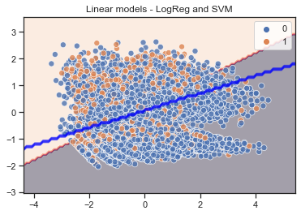

```python
## Plotting decision boundary for LR
z1 = lr.predict(np.c_[xx.ravel(), yy.ravel()])
z1 = z1.reshape(xx.shape)

## Plotting decision boundary for SVM
z2 = svm.predict(np.c_[xx.ravel(), yy.ravel()])
z2 = z2.reshape(xx.shape)

# Displaying the result
plt.contourf(xx, yy, z1, alpha=0.4); # LR
plt.contour(xx, yy, z2, alpha=0.4, colors = 'blue'); # SVM
sns.scatterplot(X[:,0], X[:,1], hue = y_train, s = 50, alpha = 0.8);
plt.title('Linear models - LogReg and SVM')
```

### More baseline models (Non-linear) : Decision Tree

```python
from sklearn.tree import DecisionTreeClassifier
```

```python
weights_dict = {0: 1.0, 1: 3.92}
weights_dict
```

```
{0: 1.0, 1: 3.92}
```

```python
## Features selected from the RFE process
selected_feats_dt
```

```
['Gender',
 'IsActiveMember',
 'country_France',
 'country_Germany',
 'country_Spain',
 'CreditScore',
 'Age',
 'Tenure',
 'Balance',
 'tenure_age_ratio']
```

```python
## Re-defining X_train and X_val to consider original unscaled continuous features. y_train and y_val remain unaffected
X_train = df_train[selected_feats_dt].values
X_val = df_val[selected_feats_dt].values
X_train.shape, y_train.shape
X_val.shape, y_val.shape
```

```
((7920, 10), (7920,))
```

```
((1080, 10), (1080,))
```

```python
clf = DecisionTreeClassifier(criterion = 'entropy', class_weight = weights_dict, max_depth = 4, max_features = None
                            , min_samples_split = 25, min_samples_leaf = 15)
```

```python
clf.fit(X_train, y_train)
```

```
DecisionTreeClassifier(class_weight={0: 1.0, 1: 3.92}, criterion='entropy',
                       max_depth=4, min_samples_leaf=15, min_samples_split=25)
```

```python
## Checking the importance of different features of the model
pd.DataFrame({'features': selected_feats,
              'importance': clf.feature_importances_
             }).sort_values(by = 'importance', ascending=False)
```

|  | features | importance |
| --- | --- | --- |
| 6 | Age | 0.731012 |
| 1 | IsActiveMember | 0.124633 |
| 3 | country_Germany | 0.098787 |
| 8 | Balance | 0.022211 |
| 0 | Gender | 0.014088 |
| 9 | tenure_age_ratio | 0.009269 |
| 2 | country_France | 0.000000 |
| 4 | country_Spain | 0.000000 |
| 5 | CreditScore | 0.000000 |
| 7 | Tenure | 0.000000 |

##### Evaluating the model - Metrics

```python
## Training metrics
get_model_metrics('DecisionTree', clf, X_train, y_train)
```

```
ROC_AUC_Score:  0.7202201918165825
Recall Score:  0.724502487562189

Confusion Matrix
      0     1
0  4519  1793
1   443  1165

Classification Report
              precision    recall  f1-score   support

           0       0.91      0.72      0.80      6312
           1       0.39      0.72      0.51      1608

    accuracy                           0.72      7920
   macro avg       0.65      0.72      0.66      7920
weighted avg       0.81      0.72      0.74      7920
```

```python
## Validation metrics
get_model_metrics('DecisionTree', clf, X_val, y_val)
```

```
ROC_AUC_Score:  0.7045749416156012
Recall Score:  0.7226890756302521

Confusion Matrix
     0    1
0  578  264
1   66  172

Classification Report
              precision    recall  f1-score   support

           0       0.90      0.69      0.78       842
           1       0.39      0.72      0.51       238

    accuracy                           0.69      1080
   macro avg       0.65      0.70      0.64      1080
weighted avg       0.79      0.69      0.72      1080
```

#### Plot decision boundaries of non-linear model

```python
from sklearn.decomposition import PCA
```

```python
pca = PCA(n_components=2)
```

```python
## Transforming the dataset using PCA
X = pca.fit_transform(X_train)
y = y_train
X_train.shape
X.shape
y.shape
```

```
(7920, 10)
```

```
(7920, 2)
```

```
(7920,)
```

```python
## Checking the variance explained by the reduced features
pca.explained_variance_ratio_
```

```
array([9.99997579e-01, 2.38976534e-06])
```

```python
# Creating a mesh region where the boundary will be plotted
x_min, x_max = X[:, 0].min() - 1, X[:, 0].max() + 1
y_min, y_max = X[:, 1].min() - 1, X[:, 1].max() + 1
xx, yy = np.meshgrid(np.arange(x_min, x_max, 100),
                     np.arange(y_min, y_max, 100))
```

```python
## Fitting tree model on 2 features
clf.fit(X, y)
```

```
DecisionTreeClassifier(class_weight={0: 1.0, 1: 3.92}, criterion='entropy',
                       max_depth=4, min_samples_leaf=15, min_samples_split=25)
```

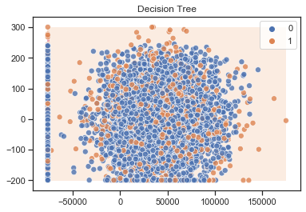

```python
## Plotting decision boundary for Decision Tree (DT)
z = clf.predict(np.c_[xx.ravel(), yy.ravel()])
z = z.reshape(xx.shape)

# Displaying the result
plt.contourf(xx, yy, z, alpha=0.4); # DT
sns.scatterplot(X[:,0], X[:,1], hue = y_train, s = 50, alpha = 0.8);
plt.title('Decision Tree');
```

#### Decision tree rule engine visualization

```python
from sklearn.tree import export_graphviz
import subprocess
```

```python
clf = DecisionTreeClassifier(criterion = 'entropy', class_weight = weights_dict, max_depth = 3, max_features = None
                            , min_samples_split = 25, min_samples_leaf = 15)

clf.fit(X_train, y_train)
```

```
DecisionTreeClassifier(class_weight={0: 1.0, 1: 3.92}, criterion='entropy',
                       max_depth=3, min_samples_leaf=15, min_samples_split=25)
```

```python
## Export as dot file
dot_data = export_graphviz(clf, out_file = 'tree.dot'
                          , feature_names = selected_feats_dt
                          , class_names = ['Did not churn', 'Churned']
                          , rounded = True, proportion = False
                          , precision = 2, filled = True)
```

```python
import os
os.environ["PATH"] += os.pathsep + 'C:/Program Files (x86)/graphviz-2.44.2_dev.20201104.1627-win32/Graphviz/bin'
```

```python
## Convert to png using system command (requires Graphviz)
subprocess.run(['dot', '-Tpng','tree.dot', '-o', 'tree.png', '-Gdpi=600'])
```

```
CompletedProcess(args=['dot', '-Tpng', 'tree.dot', '-o', 'tree.png', '-Gdpi=600'], returncode=0)
```

```python
## Display the rule-set of a single tree
from IPython.display import Image
Image(filename = 'tree.png')
```

[output not shown]

### Spot-checking various ML algorithms

**Steps** :

- Automate data preparation and model run through Pipelines
- Generate multiple models : List of all models to compare/spot-check
- Evaluate using k-fold Cross validation framework

**Note** : Restart the kernel and read the original dataset again followed by train-test split and then come directly to this section of the notebook

#### Automating data preparation and model run through Pipelines

```python
from sklearn.base import BaseEstimator, TransformerMixin
```

```python
class CategoricalEncoder(BaseEstimator, TransformerMixin):
    """
    Encodes categorical columns using LabelEncoding, OneHotEncoding and TargetEncoding.
    LabelEncoding is used for binary categorical columns
    OneHotEncoding is used for columns with <= 10 distinct values
    TargetEncoding is used for columns with higher cardinality (>10 distinct values)

    """

    def __init__(self, cols = None, lcols = None, ohecols = None, tcols = None, reduce_df = False):
        """

        Parameters
        ----------
        cols : list of str
            Columns to encode.  Default is to one-hot/target/label encode all categorical columns in the DataFrame.
        reduce_df : bool
            Whether to use reduced degrees of freedom for encoding
            (that is, add N-1 one-hot columns for a column with N
            categories). E.g. for a column with categories A, B,
            and C: When reduce_df is True, A=[1, 0], B=[0, 1],
            and C=[0, 0].  When reduce_df is False, A=[1, 0, 0],
            B=[0, 1, 0], and C=[0, 0, 1]
            Default = False

        """

        if isinstance(cols,str):
            self.cols = [cols]
        else :
            self.cols = cols

        if isinstance(lcols,str):
            self.lcols = [lcols]
        else :
            self.lcols = lcols

        if isinstance(ohecols,str):
            self.ohecols = [ohecols]
        else :
            self.ohecols = ohecols

        if isinstance(tcols,str):
            self.tcols = [tcols]
        else :
            self.tcols = tcols

        self.reduce_df = reduce_df


    def fit(self, X, y):
        """Fit label/one-hot/target encoder to X and y

        Parameters
        ----------
        X : pandas DataFrame, shape [n_samples, n_columns]
            DataFrame containing columns to encode
        y : pandas Series, shape = [n_samples]
            Target values.

        Returns
        -------
        self : encoder
            Returns self.
        """

        # Encode all categorical cols by default
        if self.cols is None:
            self.cols = [c for c in X if str(X[c].dtype)=='object']

        # Check columns are in X
        for col in self.cols:
            if col not in X:
                raise ValueError('Column \''+col+'\' not in X')

        # Separating out lcols, ohecols and tcols
        if self.lcols is None:
            self.lcols = [c for c in self.cols if X[c].nunique() <= 2]

        if self.ohecols is None:
            self.ohecols = [c for c in self.cols if ((X[c].nunique() > 2) & (X[c].nunique() <= 10))]

        if self.tcols is None:
            self.tcols = [c for c in self.cols if X[c].nunique() > 10]


        ## Create Label Encoding mapping
        self.lmaps = dict()
        for col in self.lcols:
            self.lmaps[col] = dict(zip(X[col].values, X[col].astype('category').cat.codes.values))


        ## Create OneHot Encoding mapping
        self.ohemaps = dict() #dict to store map for each column
        for col in self.ohecols:
            self.ohemaps[col] = []
            uniques = X[col].unique()
            for unique in uniques:
                self.ohemaps[col].append(unique)
            if self.reduce_df:
                del self.ohemaps[col][-1]


        ## Create Target Encoding mapping
        self.global_target_mean = y.mean().round(2)
        self.sum_count = dict()
        for col in self.tcols:
            self.sum_count[col] = dict()
            uniques = X[col].unique()
            for unique in uniques:
                ix = X[col]==unique
                self.sum_count[col][unique] = (y[ix].sum(),ix.sum())


        ## Return the fit object
        return self


    def transform(self, X, y=None):
        """Perform label/one-hot/target encoding transformation.

        Parameters
        ----------
        X : pandas DataFrame, shape [n_samples, n_columns]
            DataFrame containing columns to label encode

        Returns
        -------
        pandas DataFrame
            Input DataFrame with transformed columns
        """

        Xo = X.copy()
        ## Perform label encoding transformation
        for col, lmap in self.lmaps.items():

            # Map the column
            Xo[col] = Xo[col].map(lmap)
            Xo[col].fillna(-1, inplace=True) ## Filling new values with -1


        ## Perform one-hot encoding transformation
        for col, vals in self.ohemaps.items():
            for val in vals:
                new_col = col+'_'+str(val)
                Xo[new_col] = (Xo[col]==val).astype('uint8')
            del Xo[col]


        ## Perform LOO target encoding transformation
        # Use normal target encoding if this is test data
        if y is None:
            for col in self.sum_count:
                vals = np.full(X.shape[0], np.nan)
                for cat, sum_count in self.sum_count[col].items():
                    vals[X[col]==cat] = (sum_count[0]/sum_count[1]).round(2)
                Xo[col] = vals
                Xo[col].fillna(self.global_target_mean, inplace=True) # Filling new values by global target mean

        # LOO target encode each column
        else:
            for col in self.sum_count:
                vals = np.full(X.shape[0], np.nan)
                for cat, sum_count in self.sum_count[col].items():
                    ix = X[col]==cat
                    if sum_count[1] > 1:
                        vals[ix] = ((sum_count[0]-y[ix].reshape(-1,))/(sum_count[1]-1)).round(2)
                    else :
                        vals[ix] = ((y.sum() - y[ix])/(X.shape[0] - 1)).round(2) # Catering to the case where a particular
                                                                                 # category level occurs only once in the dataset

                Xo[col] = vals
                Xo[col].fillna(self.global_target_mean, inplace=True) # Filling new values by global target mean


        ## Return encoded DataFrame
        return Xo


    def fit_transform(self, X, y=None):
        """Fit and transform the data via label/one-hot/target encoding.

        Parameters
        ----------
        X : pandas DataFrame, shape [n_samples, n_columns]
            DataFrame containing columns to encode
        y : pandas Series, shape = [n_samples]
            Target values (required!).

        Returns
        -------
        pandas DataFrame
            Input DataFrame with transformed columns
        """

        return self.fit(X, y).transform(X, y)
```

```python
class AddFeatures(BaseEstimator):
    """
    Add new, engineered features using original categorical and numerical features of the DataFrame
    """

    def __init__(self, eps = 1e-6):
        """
        Parameters
        ----------
        eps : A small value to avoid divide by zero error. Default value is 0.000001
        """

        self.eps = eps


    def fit(self, X, y=None):
        return self


    def transform(self, X):
        """
        Parameters
        ----------
        X : pandas DataFrame, shape [n_samples, n_columns]
            DataFrame containing base columns using which new interaction-based features can be engineered
        """
        Xo = X.copy()
        ## Add 4 new columns - bal_per_product, bal_by_est_salary, tenure_age_ratio, age_surname_mean_churn
        Xo['bal_per_product'] = Xo.Balance/(Xo.NumOfProducts + self.eps)
        Xo['bal_by_est_salary'] = Xo.Balance/(Xo.EstimatedSalary + self.eps)
        Xo['tenure_age_ratio'] = Xo.Tenure/(Xo.Age + self.eps)

        ## Returning the updated dataframe
        return Xo


    def fit_transform(self, X, y=None):
        """
        Parameters
        ----------
        X : pandas DataFrame, shape [n_samples, n_columns]
            DataFrame containing base columns using which new interaction-based features can be engineered
        """
        return self.fit(X,y).transform(X)
```

```python
class CustomScaler(BaseEstimator, TransformerMixin):
    """
    A custom standard scaler class with the ability to apply scaling on selected columns
    """

    def __init__(self, scale_cols = None):
        """
        Parameters
        ----------
        scale_cols : list of str
            Columns on which to perform scaling and normalization. Default is to scale all numerical columns

        """
        self.scale_cols = scale_cols


    def fit(self, X, y=None):
        """
        Parameters
        ----------
        X : pandas DataFrame, shape [n_samples, n_columns]
            DataFrame containing columns to scale
        """

        # Scaling all non-categorical columns if user doesn't provide the list of columns to scale
        if self.scale_cols is None:
            self.scale_cols = [c for c in X if ((str(X[c].dtype).find('float') != -1) or (str(X[c].dtype).find('int') != -1))]


        ## Create mapping corresponding to scaling and normalization
        self.maps = dict()
        for col in self.scale_cols:
            self.maps[col] = dict()
            self.maps[col]['mean'] = np.mean(X[col].values).round(2)
            self.maps[col]['std_dev'] = np.std(X[col].values).round(2)

        # Return fit object
        return self


    def transform(self, X):
        """
        Parameters
        ----------
        X : pandas DataFrame, shape [n_samples, n_columns]
            DataFrame containing columns to scale
        """
        Xo = X.copy()

        ## Map transformation to respective columns
        for col in self.scale_cols:
            Xo[col] = (Xo[col] - self.maps[col]['mean']) / self.maps[col]['std_dev']


        # Return scaled and normalized DataFrame
        return Xo


    def fit_transform(self, X, y=None):
        """
        Parameters
        ----------
        X : pandas DataFrame, shape [n_samples, n_columns]
            DataFrame containing columns to scale
        """
        # Fit and return transformed dataframe
        return self.fit(X).transform(X)
```

#### Pipeline in action for a single model

```python
from sklearn.pipeline import Pipeline
from sklearn.tree import DecisionTreeClassifier

## Importing relevant metrics
from sklearn.metrics import roc_auc_score, f1_score, recall_score, confusion_matrix, classification_report
```

```python
X = df_train.drop(columns = ['Exited'], axis = 1)
X_val = df_val.drop(columns = ['Exited'], axis = 1)

cols_to_scale = ['CreditScore', 'Age', 'Balance', 'EstimatedSalary', 'bal_per_product', 'bal_by_est_salary', 'tenure_age_ratio' ]
```

```python
weights_dict = {0 : 1.0, 1 : 3.92}

clf = DecisionTreeClassifier(criterion = 'entropy', class_weight = weights_dict, max_depth = 4, max_features = None
                            , min_samples_split = 25, min_samples_leaf = 15)
```

```python
model = Pipeline(steps = [('categorical_encoding', CategoricalEncoder()),
                          ('add_new_features', AddFeatures()),
                          ('standard_scaling', CustomScaler(cols_to_scale)),
                          ('classifier', clf)
                         ])
```

```python
# Fit pipeline with training data
model.fit(X,y_train)
```

```python
## Validation metrics
get_model_metrics('Piepline', model, X_val, y_val)
```

[output not shown]

### Pipeline with k-fold Cross Validation

Models : RF, LGBM, XGB, Naive Bayes (Gaussian/Multinomial), kNN

```python
from sklearn.model_selection import cross_val_score
```

```python
## Preparing data and a few common model parameters
X = df_train.drop(columns = ['Exited'], axis = 1)
y = y_train.ravel()

weights_dict = {0 : 1.0, 1 : 3.93}
_, num_samples = np.unique(y_train, return_counts = True)
weight = (num_samples[0]/num_samples[1]).round(2)
weight

cols_to_scale = ['CreditScore', 'Age', 'Balance', 'EstimatedSalary', 'bal_per_product', 'bal_by_est_salary', 'tenure_age_ratio']
```

```python
## Importing the models to be tried out
from sklearn.ensemble import RandomForestClassifier, ExtraTreesClassifier
from lightgbm import LGBMClassifier
from xgboost import XGBClassifier
from sklearn.neighbors import KNeighborsClassifier
from sklearn.naive_bayes import GaussianNB, MultinomialNB, ComplementNB, BernoulliNB
```

```python
## Preparing a list of models to try out in the spot-checking process
def generate_models(models = dict()):
    # Tree models
    for n_trees in [21, 1001]:
        models['rf_' + str(n_trees)] = RandomForestClassifier(n_estimators = n_trees, n_jobs = -1, criterion = 'entropy'
                                                              , class_weight = weights_dict, max_depth = 6, max_features = 0.6
                                                              , min_samples_split = 30, min_samples_leaf = 20)

        models['lgb_' + str(n_trees)] = LGBMClassifier(boosting_type='dart', num_leaves=31, max_depth= 6, learning_rate=0.1
                                                       , n_estimators=n_trees, class_weight=weights_dict, min_child_samples=20
                                                       , colsample_bytree=0.6, reg_alpha=0.3, reg_lambda=1.0, n_jobs=- 1
                                                       , importance_type = 'gain')

        models['xgb_' + str(n_trees)] = XGBClassifier(objective='binary:logistic', n_estimators = n_trees, max_depth = 6
                                                      , learning_rate = 0.03, n_jobs = -1, colsample_bytree = 0.6
                                                      , reg_alpha = 0.3, reg_lambda = 0.1, scale_pos_weight = weight)

        models['et_' + str(n_trees)] = ExtraTreesClassifier(n_estimators=n_trees, criterion = 'entropy', max_depth = 6
                                                            , max_features = 0.6, n_jobs = -1, class_weight = weights_dict
                                                            , min_samples_split = 30, min_samples_leaf = 20)

    # kNN models
    for n in [3,5,11]:
        models['knn_' + str(n)] = KNeighborsClassifier(n_neighbors=n)

    # Naive-Bayes models
    models['gauss_nb'] = GaussianNB()
    models['multi_nb'] = MultinomialNB()
    models['compl_nb'] = ComplementNB()
    models['bern_nb'] = BernoulliNB()

    return models
```

```python
## Automation of data preparation and model run through pipelines
def make_pipeline(model):
    '''
    Creates pipeline for the model passed as the argument. Uses standard scaling only in case of kNN models.
    Ignores scaling step for tree/Naive Bayes models
    '''

    if (str(model).find('KNeighborsClassifier') != -1):
        pipe =  Pipeline(steps = [ ('add_new_features', AddFeatures()),
                              ('standard_scaling', CustomScaler(cols_to_scale)),
                              ('classifier', model)
                             ])
    else :
        pipe =  Pipeline(steps = [('add_new_features', AddFeatures()),
                              ('classifier', model)
                             ])


    return pipe
```

```python
## Run/Evaluate all 15 models using KFold cross-validation (5 folds)
def evaluate_models(X, y, models, folds = 5, metric = 'recall'):
    results = dict()
    for name, model in models.items():
        # Evaluate model through automated pipelines
        pipeline = make_pipeline(model)
        scores = cross_val_score(pipeline, X, y, cv = folds, scoring = metric, n_jobs = -1)

        # Store results of the evaluated model
        results[name] = scores
        mu, sigma = np.mean(scores), np.std(scores)
        # Printing individual model results
        print('Model {}: mean = {}, std_dev = {}'.format(name, mu, sigma))

    return results
```

```python
## Spot-checking in action
models = generate_models()
print('Recall metric')
results = evaluate_models(X, y , models, metric = 'recall')
print('F1-score metric')
results = evaluate_models(X, y , models, metric = 'f1')
```

[output not shown]

Based on the relevant metric, a suitable model can be chosen for further hyperparameter tuning.

LightGBM is chosen for further hyperparameter tuning because it has the best performance on recall metric and it came close second when comparing using F1-scores

```python
pd.DataFrame(results).T
```

|  | 0 | 1 | 2 | 3 | 4 |
| --- | --- | --- | --- | --- | --- |
| rf_21 | 0.580153 | 0.593985 | 0.605598 | 0.600249 | 0.592593 |
| lgb_21 | 0.581218 | 0.594527 | 0.591304 | 0.609453 | 0.601990 |
| xgb_21 | 0.587933 | 0.592308 | 0.594388 | 0.616541 | 0.605830 |
| et_21 | 0.581509 | 0.585956 | 0.603295 | 0.594328 | 0.585542 |
| rf_1001 | 0.584930 | 0.587805 | 0.606827 | 0.608589 | 0.597964 |
| lgb_1001 | 0.582202 | 0.617910 | 0.586667 | 0.625378 | 0.598266 |
| xgb_1001 | 0.609795 | 0.629630 | 0.593607 | 0.617284 | 0.590015 |
| et_1001 | 0.589681 | 0.599746 | 0.600255 | 0.602740 | 0.576313 |
| knn_3 | 0.414487 | 0.464491 | 0.434457 | 0.448343 | 0.453184 |
| knn_5 | 0.379310 | 0.453061 | 0.400818 | 0.443515 | 0.436735 |
| knn_11 | 0.370370 | 0.421978 | 0.336406 | 0.364055 | 0.420131 |
| gauss_nb | 0.071429 | 0.104987 | 0.045977 | 0.038462 | 0.045198 |
| multi_nb | 0.314976 | 0.349328 | 0.325626 | 0.324930 | 0.331502 |
| compl_nb | 0.314976 | 0.349328 | 0.325626 | 0.324930 | 0.331502 |
| bern_nb | 0.343470 | 0.332103 | 0.315271 | 0.342373 | 0.364228 |

### Hyperparameter tuning

RandomSearchCV vs GridSearchCV

- Random Search is more suitable for large datasets, with a large number of parameter settings
- Grid Search results in a more precise hyperparameter tuning, thus resulting in better model performance. Intelligent tuning mechanism can also help reduce the time taken in GridSearch by a large factor
- Will optimize on F1 metric. We could easily reach 75% Recall from the default parameters as seen earlier

```python
from sklearn.pipeline import Pipeline
from sklearn.model_selection import GridSearchCV, RandomizedSearchCV
from lightgbm import LGBMClassifier
```

```python
## Preparing data and a few common model parameters
# Unscaled features will be used since it's a tree model

X_train = df_train.drop(columns = ['Exited'], axis = 1)
X_val = df_val.drop(columns = ['Exited'], axis = 1)

X_train.shape, y_train.shape
X_val.shape, y_val.shape
```

```
((7920, 15), (7920,))
```

```
((1080, 15), (1080,))
```

```python
lgb = LGBMClassifier(boosting_type = 'dart', min_child_samples = 20, n_jobs = - 1, importance_type = 'gain', num_leaves = 31)
```

```python
model = Pipeline(steps = [('categorical_encoding', CategoricalEncoder()),
                          ('add_new_features', AddFeatures()),
                          ('classifier', lgb)
                         ])
```

#### Randomized Search

```python
## Exhaustive list of parameters
parameters = {'classifier__n_estimators':[10, 21, 51, 100, 201, 350, 501]
             ,'classifier__max_depth': [3, 4, 6, 9]
             ,'classifier__num_leaves':[7, 15, 31]
             ,'classifier__learning_rate': [0.03, 0.05, 0.1, 0.5, 1]
             ,'classifier__colsample_bytree': [0.3, 0.6, 0.8]
             ,'classifier__reg_alpha': [0, 0.3, 1, 5]
             ,'classifier__reg_lambda': [0.1, 0.5, 1, 5, 10]
             ,'classifier__class_weight': [{0:1,1:1.0}, {0:1,1:1.96}, {0:1,1:3.0}, {0:1,1:3.93}]
             }
```

```python
search = RandomizedSearchCV(model, parameters, n_iter = 20, cv = 5, scoring = 'f1')
```

```python
search.fit(X_train, y_train.ravel())
```

[output not shown]

```
RandomizedSearchCV(cv=5,
                   estimator=Pipeline(steps=[('categorical_encoding',
                                              CategoricalEncoder()),
                                             ('add_new_features',
                                              AddFeatures()),
                                             ('classifier',
                                              LGBMClassifier(boosting_type='dart',
                                                             importance_type='gain'))]),
                   n_iter=20,
                   param_distributions={'classifier__class_weight': [{0: 1,
                                                                      1: 1.0},
                                                                     {0: 1,
                                                                      1: 1.96},
                                                                     {0: 1,
                                                                      1: 3.0},
                                                                     {0: 1,
                                                                      1: 3.93}],
                                        'classifier__colsample_bytree': [0.3,
                                                                         0.6,
                                                                         0.8],
                                        'classifier__learning_rate': [0.03,
                                                                      0.05, 0.1,
                                                                      0.5, 1],
                                        'classifier__max_depth': [3, 4, 6, 9],
                                        'classifier__n_estimators': [10, 21, 51,
                                                                     100, 201,
                                                                     350, 501],
                                        'classifier__num_leaves': [7, 15, 31],
                                        'classifier__reg_alpha': [0, 0.3, 1, 5],
                                        'classifier__reg_lambda': [0.1, 0.5, 1,
                                                                   5, 10]},
                   scoring='f1')
```

```python
search.best_params_
search.best_score_
```

```
{'classifier__reg_lambda': 0.1,
 'classifier__reg_alpha': 1,
 'classifier__num_leaves': 31,
 'classifier__n_estimators': 201,
 'classifier__max_depth': 9,
 'classifier__learning_rate': 0.03,
 'classifier__colsample_bytree': 0.6,
 'classifier__class_weight': {0: 1, 1: 1.96}}
```

```
0.6260481971686006
```

```python
search.cv_results_
```

[output not shown]

[output cut: 212 more lines]

[output not shown]

#### Grid Search

```python
## Current list of parameters
parameters = {'classifier__n_estimators':[201]
             ,'classifier__max_depth': [6]
             ,'classifier__num_leaves': [63]
             ,'classifier__learning_rate': [0.1]
             ,'classifier__colsample_bytree': [0.6, 0.8]
             ,'classifier__reg_alpha': [0, 1, 10]
             ,'classifier__reg_lambda': [0.1, 1, 5]
             ,'classifier__class_weight': [{0:1,1:3.0}]
             }
```

```python
grid = GridSearchCV(model, parameters, cv = 5, scoring = 'f1', n_jobs = -1)
```

```python
grid.fit(X_train, y_train.ravel())
```

```
GridSearchCV(cv=5,
             estimator=Pipeline(steps=[('categorical_encoding',
                                        CategoricalEncoder()),
                                       ('add_new_features', AddFeatures()),
                                       ('classifier',
                                        LGBMClassifier(boosting_type='dart',
                                                       importance_type='gain'))]),
             n_jobs=-1,
             param_grid={'classifier__class_weight': [{0: 1, 1: 3.0}],
                         'classifier__colsample_bytree': [0.6, 0.8],
                         'classifier__learning_rate': [0.1],
                         'classifier__max_depth': [6],
                         'classifier__n_estimators': [201],
                         'classifier__num_leaves': [63],
                         'classifier__reg_alpha': [0, 1, 10],
                         'classifier__reg_lambda': [0.1, 1, 5]},
             scoring='f1')
```

```python
grid.best_params_
grid.best_score_
```

```
{'classifier__class_weight': {0: 1, 1: 3.0},
 'classifier__colsample_bytree': 0.6,
 'classifier__learning_rate': 0.1,
 'classifier__max_depth': 6,
 'classifier__n_estimators': 201,
 'classifier__num_leaves': 63,
 'classifier__reg_alpha': 1,
 'classifier__reg_lambda': 1}
```

```
0.6237868008582461
```

```python
grid.cv_results_
```

[output not shown]

[output cut: 194 more lines]

[output not shown]

### Can we do better? - Ensembles

```python
from lightgbm import LGBMClassifier
from sklearn.pipeline import Pipeline
```

```python
## Preparing data for error analysis
# Unscaled features will be used since it's a tree model

X_train = df_train.drop(columns = ['Exited'], axis = 1)
X_val = df_val.drop(columns = ['Exited'], axis = 1)

X_train.shape, y_train.shape
X_val.shape, y_val.shape
```

```
((7920, 15), (7920,))
```

```
((1080, 15), (1080,))
```

```python
## Three versions of the final model with best params for F1-score metric

# Equal weights to both target classes (no class imbalance correction)
lgb1 = LGBMClassifier(boosting_type = 'dart', class_weight = {0: 1, 1: 1}, min_child_samples = 20, n_jobs = - 1
                     , importance_type = 'gain', max_depth = 4, num_leaves = 31, colsample_bytree = 0.6, learning_rate = 0.1
                     , n_estimators = 21, reg_alpha = 0, reg_lambda = 0.5)

# Addressing class imbalance completely by weighting the undersampled class by the class imbalance ratio
lgb2 = LGBMClassifier(boosting_type = 'dart', class_weight = {0: 1, 1: 3.93}, min_child_samples = 20, n_jobs = - 1
                     , importance_type = 'gain', max_depth = 6, num_leaves = 63, colsample_bytree = 0.6, learning_rate = 0.1
                     , n_estimators = 201, reg_alpha = 1, reg_lambda = 1)


# Best class_weight parameter settings (partial class imbalance correction)
lgb3 = LGBMClassifier(boosting_type = 'dart', class_weight = {0: 1, 1: 3.0}, min_child_samples = 20, n_jobs = - 1
                     , importance_type = 'gain', max_depth = 6, num_leaves = 63, colsample_bytree = 0.6, learning_rate = 0.1
                     , n_estimators = 201, reg_alpha = 1, reg_lambda = 1)
```

```python
## 3 different Pipeline objects for the 3 models defined above
model_1 = Pipeline(steps = [('categorical_encoding', CategoricalEncoder()),
                          ('add_new_features', AddFeatures()),
                          ('classifier', lgb1)
                         ])

model_2 = Pipeline(steps = [('categorical_encoding', CategoricalEncoder()),
                          ('add_new_features', AddFeatures()),
                          ('classifier', lgb2)
                         ])

model_3 = Pipeline(steps = [('categorical_encoding', CategoricalEncoder()),
                          ('add_new_features', AddFeatures()),
                          ('classifier', lgb3)
                         ])
```

```python
## Fitting each of these models
model_1.fit(X_train, y_train.ravel())
model_2.fit(X_train, y_train.ravel())
model_3.fit(X_train, y_train.ravel())
```

```
Pipeline(steps=[('categorical_encoding',
                 CategoricalEncoder(cols=[], lcols=[], ohecols=[], tcols=[])),
                ('add_new_features', AddFeatures()),
                ('classifier',
                 LGBMClassifier(boosting_type='dart', class_weight={0: 1, 1: 1},
                                colsample_bytree=0.6, importance_type='gain',
                                max_depth=4, n_estimators=21, reg_alpha=0,
                                reg_lambda=0.5))])
```

```
Pipeline(steps=[('categorical_encoding',
                 CategoricalEncoder(cols=[], lcols=[], ohecols=[], tcols=[])),
                ('add_new_features', AddFeatures()),
                ('classifier',
                 LGBMClassifier(boosting_type='dart',
                                class_weight={0: 1, 1: 3.93},
                                colsample_bytree=0.6, importance_type='gain',
                                max_depth=6, n_estimators=201, num_leaves=63,
                                reg_alpha=1, reg_lambda=1))])
```

```
Pipeline(steps=[('categorical_encoding',
                 CategoricalEncoder(cols=[], lcols=[], ohecols=[], tcols=[])),
                ('add_new_features', AddFeatures()),
                ('classifier',
                 LGBMClassifier(boosting_type='dart',
                                class_weight={0: 1, 1: 3.0},
                                colsample_bytree=0.6, importance_type='gain',
                                max_depth=6, n_estimators=201, num_leaves=63,
                                reg_alpha=1, reg_lambda=1))])
```

```python
## Getting prediction probabilities from each of these models
m1_pred_probs_trn = model_1.predict_proba(X_train)
m2_pred_probs_trn = model_2.predict_proba(X_train)
m3_pred_probs_trn = model_3.predict_proba(X_train)
```

```python
## Checking correlations between the predictions of the 3 models
df_t = pd.DataFrame({'m1_pred': m1_pred_probs_trn[:,1], 'm2_pred': m2_pred_probs_trn[:,1], 'm3_pred': m3_pred_probs_trn[:,1]})
df_t.shape
df_t.corr()
```

```
(7920, 3)
```

|  | m1_pred | m2_pred | m3_pred |
| --- | --- | --- | --- |
| m1_pred | 1.000000 | 0.913371 | 0.926834 |
| m2_pred | 0.913371 | 1.000000 | 0.994078 |
| m3_pred | 0.926834 | 0.994078 | 1.000000 |

Although models m1 and m2 are highly correlated (0.9), they are still less closely associated than m2 and m3. Thus, we'll try to form an ensemble of m1 and m2 (model averaging/stacking) and see if that improves the model accuracy

```python
## Getting prediction probabilities from each of these models
m1_pred_probs_val = model_1.predict_proba(X_val)
m2_pred_probs_val = model_2.predict_proba(X_val)
m3_pred_probs_val = model_3.predict_proba(X_val)
```

```python
threshold = 0.5
```

```python
## Best model (Model 3) predictions
m3_preds = np.where(m3_pred_probs_val[:,1] >= threshold, 1, 0)
```

```python
## Model averaging predictions (Weighted average)
m1_m2_preds = np.where(((0.1*m1_pred_probs_val[:,1]) + (0.9*m2_pred_probs_val[:,1])) >= threshold, 1, 0)
```

```python
## Model 3 (Best model, tuned by GridSearch) performance on validation set
get_metrics(y_val, m3_preds)
recall_score(y_val, m3_preds)
confusion_matrix(y_val, m3_preds)
print(classification_report(y_val, m3_preds))
```

```
ROC_AUC_Score:  0.7671610211780674
Recall Score:  0.6554621848739496

Confusion Matrix
     0    1
0  740  102
1   82  156

Classification Report
              precision    recall  f1-score   support

           0       0.90      0.88      0.89       842
           1       0.60      0.66      0.63       238

    accuracy                           0.83      1080
   macro avg       0.75      0.77      0.76      1080
weighted avg       0.84      0.83      0.83      1080
```

```
0.6554621848739496
```

```
array([[740, 102],
       [ 82, 156]], dtype=int64)
```

```
              precision    recall  f1-score   support

           0       0.90      0.88      0.89       842
           1       0.60      0.66      0.63       238

    accuracy                           0.83      1080
   macro avg       0.75      0.77      0.76      1080
weighted avg       0.84      0.83      0.83      1080
```

```python
## Ensemble model prediction on validation set
get_metrics(y_val, m1_m2_preds)
```

```
ROC_AUC_Score:  0.7696710513183895
Recall Score:  0.680672268907563

Confusion Matrix
     0    1
0  723  119
1   76  162

Classification Report
              precision    recall  f1-score   support

           0       0.90      0.86      0.88       842
           1       0.58      0.68      0.62       238

    accuracy                           0.82      1080
   macro avg       0.74      0.77      0.75      1080
weighted avg       0.83      0.82      0.82      1080
```

#### Model stacking

The base models are the 2 LightGBM models with different class_weights parameters. They are stacked on top by a logistic regression model. Other models like linear SVM/Decision Trees can also be used. But since there are only 2 features for the model at stacking layer, it's better to use the simplest model available.

For training, we have the predictions from the 2 models on the train set. They go in as the input to the next layer of the Ensemble, which is the logistic regression model, and train the LogReg model

For prediction, we first predict using the 2 LGBM models on the validation set. The predictions from the two models go as inputs to the logistic regression which gives out the final prediction

```python
from sklearn.linear_model import LogisticRegression
```

```python
## Training
lr = LogisticRegression(C = 1.0, class_weight =  {0:1, 1:2.0})

# Concatenating the probability predictions of the 2 models on train set
X_t = np.c_[m1_pred_probs_trn[:,1],m2_pred_probs_trn[:,1]]

# Fit stacker model on top of outputs of base model
lr.fit(X_t, y_train)
```

```
LogisticRegression(class_weight={0: 1, 1: 2.0})
```

```python
## Prediction
# Concatenating outputs from both the base models on the validation set
X_t_val = np.c_[m1_pred_probs_val[:,1],m2_pred_probs_val[:,1]]

# Predict using the stacker model
m1_m2_preds = lr.predict(X_t_val)
```

```python
## Ensemble model prediction on validation set
get_metrics(y_val, m1_m2_preds)
```

```
ROC_AUC_Score:  0.7641919000379249
Recall Score:  0.6554621848739496

Confusion Matrix
     0    1
0  735  107
1   82  156

Classification Report
              precision    recall  f1-score   support

           0       0.90      0.87      0.89       842
           1       0.59      0.66      0.62       238

    accuracy                           0.82      1080
   macro avg       0.75      0.76      0.75      1080
weighted avg       0.83      0.82      0.83      1080
```

```python
# Model weights learnt by the stacker LogReg model
lr.coef_
lr.intercept_
```

```
array([[-6.90106511, 12.41446025]])
```

```
array([-5.14596111])
```

### Error analysis

```python
from lightgbm import LGBMClassifier
from sklearn.pipeline import Pipeline
```

```python
## Preparing data for error analysis
# Unscaled features will be used since it's a tree model

X_train = df_train.drop(columns = ['Exited'], axis = 1)
X_val = df_val.drop(columns = ['Exited'], axis = 1)

X_train.shape, y_train.shape
X_val.shape, y_val.shape
```

```
((7920, 15), (7920,))
```

```
((1080, 15), (1080,))
```

```python
## Final model with best params for F1-score metric

lgb = LGBMClassifier(boosting_type = 'dart', class_weight = {0: 1, 1: 3.0}, min_child_samples = 20, n_jobs = - 1
                     , importance_type = 'gain', max_depth = 6, num_leaves = 63, colsample_bytree = 0.6, learning_rate = 0.1
                     , n_estimators = 201, reg_alpha = 1, reg_lambda = 1)


model = Pipeline(steps = [('categorical_encoding', CategoricalEncoder()),
                          ('add_new_features', AddFeatures()),
                          ('classifier', lgb)
                         ])
```

```python
## Fit best model
model.fit(X_train, y_train.ravel())
```

```
Pipeline(steps=[('categorical_encoding',
                 CategoricalEncoder(cols=[], lcols=[], ohecols=[], tcols=[])),
                ('add_new_features', AddFeatures()),
                ('classifier',
                 LGBMClassifier(boosting_type='dart',
                                class_weight={0: 1, 1: 3.0},
                                colsample_bytree=0.6, importance_type='gain',
                                max_depth=6, n_estimators=201, num_leaves=63,
                                reg_alpha=1, reg_lambda=1))])
```

```python
## Making predictions on a copy of validation set
df_ea = df_val.copy()
df_ea['y_pred'] = model.predict(X_val)
df_ea['y_pred_prob'] = model.predict_proba(X_val)[:,1]
```

```python
df_ea.shape
df_ea.sample(5)
```

```
(1080, 18)
```

|  | CreditScore | Gender | Age | Tenure | Balance | NumOfProducts | HasCrCard | IsActiveMember | EstimatedSalary | Exited | country_France | country_Germany | country_Spain | bal_per_product | bal_by_est_salary | tenure_age_ratio | y_pred | y_pred_prob |
| --- | --- | --- | --- | --- | --- | --- | --- | --- | --- | --- | --- | --- | --- | --- | --- | --- | --- | --- |
| 907 | 675 | 0 | 39 | 6 | 0.00 | 2 | 0 | 0 | 83419.15 | 0 | 1.0 | 0.0 | 0.0 | 0.000000 | 0.000000 | 0.153846 | 0 | 0.126576 |
| 33 | 560 | 1 | 24 | 1 | 116084.32 | 1 | 1 | 0 | 89734.70 | 0 | 1.0 | 0.0 | 0.0 | 116084.203916 | 1.293639 | 0.041667 | 0 | 0.197379 |
| 159 | 711 | 0 | 34 | 6 | 0.00 | 2 | 1 | 1 | 175310.38 | 0 | 1.0 | 0.0 | 0.0 | 0.000000 | 0.000000 | 0.176471 | 0 | 0.065256 |
| 58 | 637 | 1 | 43 | 1 | 135645.29 | 2 | 0 | 1 | 101382.86 | 1 | 0.0 | 1.0 | 0.0 | 67822.611089 | 1.337951 | 0.023256 | 0 | 0.426969 |
| 567 | 728 | 0 | 69 | 1 | 0.00 | 2 | 1 | 1 | 131804.86 | 0 | 1.0 | 0.0 | 0.0 | 0.000000 | 0.000000 | 0.014493 | 0 | 0.041086 |

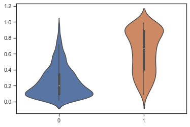

```python
## Visualizing distribution of predicted probabilities
sns.violinplot(y_val.ravel(), df_ea['y_pred_prob'].values);
```

#### Revisiting bivariate plots of important features

The difference in distribution of these features across the two classes help us to test a few hypotheses

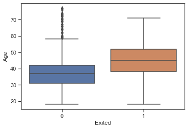

```python
sns.boxplot(x = 'Exited', y = 'Age', data = df_ea)
```

```python
## Are we able to correctly identify pockets of high-churn customer regions in feature space?
df_ea.Exited.value_counts(normalize=True).sort_index()
df_ea[(df_ea.Age > 42) & (df_ea.Age < 53)].Exited.value_counts(normalize=True).sort_index()
df_ea[(df_ea.Age > 42) & (df_ea.Age < 53)].y_pred.value_counts(normalize=True).sort_index()
```

```
0    0.77963
1    0.22037
Name: Exited, dtype: float64
```

```
0    0.560185
1    0.439815
Name: Exited, dtype: float64
```

```
0    0.421296
1    0.578704
Name: y_pred, dtype: float64
```

```python
## Checking correlation between features and target variable vs predicted variable
x = df_ea[num_feats + ['y_pred', 'Exited']].corr()
x[['y_pred','Exited']]
```

|  | y_pred | Exited |
| --- | --- | --- |
| CreditScore | -0.035617 | -0.026118 |
| Age | 0.378355 | 0.290853 |
| Tenure | -0.019997 | -0.011182 |
| Balance | 0.071107 | 0.128656 |
| NumOfProducts | -0.188807 | -0.125494 |
| EstimatedSalary | -0.018557 | -0.007971 |
| y_pred | 1.000000 | 0.519400 |
| Exited | 0.519400 | 1.000000 |